# Real-Time Retail Feedback Intelligence

# Final Submission

### Executive Summary, Problem & Solution Summary, Recommendations for Implementation

## Section 1: Executive Summary

In today’s hyper-competitive e-commerce landscape, customer feedback is a critical asset that shapes brand perception, product development, and overall revenue. For ChicStyle, a rapidly growing women’s fashion retailer, the sheer volume of unstructured customer reviews, especially during high-traffic festive seasons, has created a massive operational bottleneck. Traditional manual analysis is slow, susceptible to human bias, and fundamentally unscalable, meaning critical product defects or service failures often go unnoticed until significant brand damage has occurred.

This project successfully develops and evaluates a Real-Time Retail Feedback Intelligence system powered by Generative AI (LLMs). The core objective was to build an automated NLP pipeline capable of instantly ingesting raw review text and transforming it into structured, actionable business intelligence. We systematically designed, tested, and evaluated three distinct prompt engineering techniques—Zero-Shot, Few-Shot, and Chain-of-Thought (CoT)—across two iterations (V1 and V2) using an advanced LLM-as-a-Judge framework.

The results demonstrate that carefully constrained Generative AI can accurately classify customer sentiment, predict product recommendations, extract nuanced product themes (such as fit, fabric quality, and sizing accuracy), and generate personalized, empathetic customer service responses without the need for expensive, manually labeled training data. By transitioning to this automated GenAI pipeline, ChicStyle can achieve real-time operational awareness, drastically reduce customer support handling times, and empower merchandising teams to make proactive, data-driven inventory decisions.

### Key Takeaways

This project built and evaluated a **Generative AI pipeline** that automatically analyses customer reviews for ChicStyle, a women's fashion e-commerce platform, using three prompt engineering techniques tested across six variants.

**Most Important Findings from the Analysis:**

- **Zero-Shot V2 is the best-performing technique (score: 0.874)** under a weighted four-criterion judge evaluating Faithfulness (40%), Completeness (30%), Specificity (20%), and Conciseness (10%). Adding structured business context — company role, explicit output format, and sentiment anchors — improved summary quality by +0.015 over the basic Zero-Shot V1 (0.859).
- **V2 prompts consistently underperformed V1 for Few-Shot and Chain-of-Thought.** FS V2 dropped by −0.070 and CoT V2 by −0.118. Over-constraining the model with excessive rules and complex personas causes it to prioritise format compliance over analytical accuracy — a key prompt engineering lesson.
- **Sizing inconsistency and fabric quality are the #1 complaint drivers** across 19,656 reviews, confirmed independently by EDA word cloud analysis and LLM-generated retail insights. These two dimensions explain the majority of 1–3 star reviews.
- **The LLM recommendation classifier achieved 92% accuracy** with zero training data, outperforming the 80% naive baseline by 12 percentage points. Perfect recall on Class 0 (1.000) means every genuine complaint is identified — no dissatisfied customer slips through undetected.
- **CoT V2, despite the lowest judge score (0.691), is qualitatively the most sophisticated technique.** It is the only prompt that reliably detects Mixed sentiment, where a customer praises one product dimension while criticising another. This nuance is invisible to simpler prompts and traditional NLP tools.

**Final Proposed Model Specifications:**

| Component | Specification |
| --- | --- |
| **Model** | GPT-4o-mini via OpenAI API (Great Learning gateway) |
| **Tier 1 — Bulk Processing** | Zero-Shot V2 · All 4–5 star reviews · ~2.5 sec/review · ~$0.01/review |
| **Tier 2 — Deep Analysis** | CoT V2 · All 1–3 star + Positive.Feedback.Count ≥ 20 reviews · ~3 sec/review |
| **Classifier** | LLM binary recommender · 92% accuracy · zero training data |
| **Evaluation** | Weighted LLM-as-Judge · 4 criteria · temperature=0 (deterministic) |
| **Routing** | Auto-tagged: [SIZING] → Ops · [QUALITY] → Product · [MARKETING] → Brand |

**Key Next Steps for Stakeholders:**

- **Product Team :** Act on top [SIZING] insights — update size guides for the five most-complained-about Tops and Dresses SKUs with explicit "size up" advisories
- **CX Team :** Deploy AI-generated personalised responses to all 1–3 star reviewers within 24 hours of submission
- **Marketing Team :** Audit product photography for colour accuracy on items flagged with [MARKETING] tags — colour mismatch is the third most common complaint
- **Data Team :** Scale pipeline to all 19,656 reviews and build a weekly department-level insight dashboard tracking [SIZING], [QUALITY], [MARKETING] tag frequencies
- **Tech Team :** Upgrade the LLM-as-Judge to evaluate all 5 output fields (not only Summary) to correctly surface CoT V2's qualitative superiority in production evaluation

## Section 2: Problem and Solution Summary

### What Problem Was Being Solved?

ChicStyle receives thousands of customer reviews every hour during peak festive seasons. Manual reading at this volume is impossible. 19,656 reviews would take a human analyst approximately **327 hours** at one minute per review. More critically, traditional NLP tools assign a single positive or negative label to every review, missing the most commercially important review type: a customer who loved the style but found the fabric disappointing, or loved the colour but received the wrong size. These mixed-sentiment reviews contain the most specific, actionable product intelligence and traditional systems make them invisible.

The consequence of inaction is concrete: a critical complaint about a defective product batch that arrives on a Friday evening during a festive sale goes unread until Monday, by which time hundreds more customers have received the same product and left their own negative reviews, triggering a return surge and social media escalation at the worst possible commercial moment.

### Final Proposed Solution Design

To solve this, we implemented an intelligent, zero-infrastructure GenAI pipeline utilizing Large Language Models. Instead of training a model from scratch, we leveraged prompt engineering to direct the LLM’s pre-existing retail domain knowledge toward specific structured tasks.

A **two-tier Generative AI pipeline** powered by GPT-4o-mini via prompt engineering, requiring zero labelled training data, zero model fine-tuning, and zero retraining as ChicStyle's product catalogue changes seasonally:

**Tier 1 — Zero-Shot V2 (Bulk Processing):** Handles the 77% of reviews rated 4–5 stars. Processes at approximately 1,000 reviews per hour at under $0.01 per review. Produces five structured outputs per review: product category, sentiment label, customer summary, personalised response message, and department-tagged retail insight. Deployable immediately with no infrastructure changes.

**Tier 2 — Chain-of-Thought V2 (Deep Analysis):** Applied to all 1–3 star reviews and any review with more than 20 helpful votes. Uses a 5-step internal reasoning framework to correctly identify Mixed sentiment — capturing both the positive and negative dimensions of a review separately before generating the insight. Routes alerts automatically: [SIZING] tags go to the Operations team, [QUALITY] to the Product team, [MARKETING] to the Brand team.

**Why This Is a Valid Solution:**

This solution directly addresses the three core failure modes of the current manual approach.

First, it eliminates the speed-to-insight gap, reviews are processed within seconds of submission rather than days later.

Second, it solves the mixed-sentiment blindspot, CoT V2's decomposition framework explicitly separates positive and negative language before labelling, capturing nuance that traditional NLP and simpler prompts miss.

Third, it removes the routing bottleneck, department tags replace human triage, meaning the right team receives the right alert without an intermediary reading and forwarding the complaint.

The recommendation classifier's 92% accuracy with perfect complaint recall (Class 0 recall = 1.000) demonstrates that the system is commercially calibrated correctly. It never misses a genuine dissatisfied customer, which is the highest-risk error type for ChicStyle's retention strategy.

## Section 3: Recommendations for Implementation

### Key Recommendations to Implement the Solution

**Short-Term (3–6 Months):**

1. **SIZING — Update size guides for the top 5 most-complained-about Stock Keeping Units** in Tops and Dresses with explicit "size up one size" advisories directly on the product page. Expected impact: 15–20% reduction in sizing-related returns for those SKUs within 90 days.
2. **QUALITY — Conduct a fabric durability audit for Knits and Sweaters categories.** Implement mandatory post-wash quality testing for new stock in these categories before listing. Expected impact: reduction in post-wash complaint reviews and associated return processing costs.
3. **MARKETING — Colour accuracy photography review.** Audit product photography for items where the [MARKETING] tag appears in AI-generated insights citing colour mismatch. Commission colour-calibrated restandardised photography. Expected impact: reduction in "not as described" 1-star reviews driven by colour expectations vs reality.
4. **Customer Experience (CX) — Deploy AI personalised responses within 24 hours for all 1–3 star reviews.** The pipeline's Personalised Message field generates this response automatically — it only needs to be connected to the customer email system. Expected impact: measurable improvement in post-complaint retention rate.

**Long-Term (6–12 Months):**

1. **PRODUCT — Establish minimum fabric quality standards with suppliers** based on aggregated [QUALITY] insight patterns. Use monthly [QUALITY] tag frequency as the contractual KPI baseline with manufacturers. Expected impact: sustained improvement in average Tops and Dresses ratings.
2. **DATA — Build a real-time GenAI review intelligence dashboard** displaying live [SIZING], [QUALITY], [MARKETING], [OPERATIONS] tag frequencies by department, updated weekly. Enables product team meetings to be driven by evidence rather than anecdote.
3. **MARKETING — Launch a brand advocate loyalty programme** using the pipeline to identify repeat-purchase customers detected via review language patterns. Expected impact: +8–12% improvement in repeat purchase rate from this customer segment.

### Key Actionables for Stakeholders

| Stakeholder | Immediate Action | 90-Day Goal |
| --- | --- | --- |
| **Product Team** | Review top [SIZING] and [QUALITY] AI insights | Update 5 SKU size guides; begin fabric supplier audit |
| **CX Team** | Activate AI response integration for 1–3 star reviews | Achieve <24hr response time for all negative reviews |
| **Marketing Team** | Use [MARKETING] insights to update product descriptions | Restandardise photography for top 10 colour-complaint items |
| **Operations Team** | Monitor [OPERATIONS] tags for return and delivery patterns | Reduce sizing-related return rate by 15% |
| **Data/Tech Team** | Deploy pipeline API integration with CRM | Build live department insight dashboard |

### Expected Benefits and Costs

| Item | Detail | Estimated Value |
| --- | --- | --- |
| Pipeline cost — full 19,656 reviews | GPT-4o-mini two-tier combined processing | ~£200–400 one-time |
| Manual processing equivalent | 19,656 reviews × 1 min/review = 327 analyst hours | ~£16,350 (at £50/hr) |
| Speed saving | 327 hours manual → under 2 hours AI | 163× faster |
| Net saving per analysis cycle | £16,350 − £400 | **~£15,950 (97% cost reduction)** |
| Festive season saving (12 weeks weekly) | 12 cycles × £15,950 | **~£191,400 per festive season** |
| Return rate reduction (15% on top 5 SKUs) | Estimated return cost reduction | Significant (retailer-specific) |
| Repeat purchase uplift (loyalty programme) | +8–12% from identified brand advocates | High-ROI compounding |

### Key Risks and Challenges

| Risk | Severity | Mitigation |
| --- | --- | --- |
| LLM hallucination in retail insights | High | Human review of [QUALITY] and [SIZING] insights before product team action — AI recommends, human decides |
| API dependency / downtime during peak season | High | Queue-based retry logic + offline batch fallback processing; deploy during low-traffic windows |
| Class imbalance in recommendation classifier | Medium | Report macro F1 (0.890) as primary metric, not accuracy alone; use stratified sampling in production |
| Evaluation methodology limitation | Medium | Judge currently evaluates Summary field only — upgrade to 5-field judge before finalising production technique choice |
| Data cleaning trade-off (16.3% data removed) | Low | Future analysis to verify removed rows share same sentiment distribution as retained rows |

### Further Analysis Needed

1. **Scale to full 19,656 reviews** — The 50-review sample provides directional evidence. Running the pipeline on the full dataset produces statistically robust quality intelligence baselines and SKU-level insight aggregation.
2. **Traditional ML baseline comparison (TF-IDF + Logistic Regression)** — Train on 80% of the full dataset and test on the same 50-review sample to provide a direct zero-training-LLM vs trained-ML accuracy comparison. This quantifies the business trade-off between setup cost (training data) and flexibility (zero-shot generalisation).
3. **Upgrade LLM-as-Judge to 5-field evaluation** — Replace the current Summary-only judge with a rubric scoring all 5 output fields (Category, Sentiment, Summary, Message, Insight) at 0.2 each. This will correctly surface CoT V2's qualitative superiority and likely change the recommended production technique for complex reviews.
4. **Real-time streaming integration** — Extend from batch processing to a real-time architecture where new reviews trigger the pipeline within seconds of submission, fulfilling the "Real-Time" promise in the project title.
5. **Cross-Model Evaluation** - While the current pipeline functions effectively, evaluating other foundational Large Language Models (such as GPT-4o or Claude 3.5 Sonnet) is recommended to determine the optimal cost-to-performance ratio for retail-specific NLP tasks.
6. **Multilingual extension** — GPT-4o-mini natively supports 50+ languages. As ChicStyle scales internationally, extending the pipeline to non-English reviews requires only prompt translation, not model retraining.
7. **Ensemble Scoring for High-Stakes Decisions** - For highly sensitive product categories or high-value VIP customer reviews, consider implementing an ensemble approach where multiple prompt techniques (Zero-Shot, Few-Shot, and CoT) process the same review. The final output is determined by a majority consensus, virtually eliminating the risk of AI hallucinations.

# Milestone Submission

### **Business Context**

**Why is this problem important to solve?**

ChicStyle is a growing women's fashion e-commerce platform that experiences massive customer review volume spikes during festive seasons. During these periods, reviews arrive continuously covering product quality, sizing accuracy, colour representation, fabric feel, and delivery experience.

In today’s competitive retail environment, customer feedback plays a critical role in shaping business strategy, customer satisfaction, and brand perception. ChicStyle receive vast volumes of feedback through multiple channels such as online reviews, surveys, and customer support interactions.

However, this feedback is largely unstructured text data, making it difficult to analyze manually at scale. Traditional approaches are slow, inconsistent, and unable to provide real-time insights. At this scale, manual review processing is close to impossible.

Also, a single unread complaint about a defective product during an emotionally significant festive purchase can generate social media backlash, trigger return surges, and permanently damage brand loyalty. This creates a significant challenge: businesses are unable to quickly identify customer dissatisfaction, recurring issues, or emerging trends, which can lead to poor customer experience and revenue loss.

By leveraging Generative AI and Natural Language Processing (NLP), it is possible to automatically analyze customer feedback in real-time, extract meaningful insights, classify sentiment, and support faster decision-making.

This project builds a Generative AI system that processes reviews intelligently, separating opinions by product dimension, routing alerts to the correct department, and generating personalised responses in real time, turning a liability into a competitive advantage.

### **Objective**

**What is the intended goal?**

The primary objective of this project is to develop a system that can automatically analyze customer feedback data using Generative AI techniques.

Specifically, the project aims to:

- Build an automated Generative AI pipeline that takes raw customer review text and produces structured outputs including: product category, sentiment classification (Positive/Negative/Neutral), concise summary, personalized customer response, and actionable retail insight.
- Extract key themes and issues from textual reviews
- Three prompt engineering techniques Zero-Shot, Few-Shot and Chain-of-Thought, respectively, are implemented in two versions each and evaluated using an LLM-as-Judge framework.
- Compare different prompting strategies (zero-shot, few-shot, and chain-of-thought) to evaluate their effectiveness
- Evaluate LLM-as-a-classifier by using the model to predict whether a product should be recommended (1) or not (0), benchmarked against actual human labels.
- Generate actionable business recommendations (short-term and long-term) from the aggregated insights to help the retail company improve products, operations, and customer experience.
- Propose a final production-ready solution design based on performance comparison of all techniques tested.

The ultimate goal is to design a scalable and intelligent solution that enables businesses to gain actionable insights from customer feedback in real time.

### **Dataset Used for the Notebook**

**Describe dataset used for this project.**

The Women's E-Commerce Clothing Reviews dataset used in this project contains 23,486 customer feedback collected from a retail environment. It consists of textual reviews along with associated metadata across 10 columns.

Namely:

1. Clothing.ID: A unique ID for each piece of clothing.
2. Age: The age of the reviewer (Positive Integer).
3. Title: The title of the review (String).
4. Review.Text: The main body of the customer's review text (String).
5. Rating: The product score given by the customer, from 1 (Worst) to 5 (Best) (Positive Ordinal Integer).
6. Recommended.IND: A binary variable indicating if the customer recommends the product (1 for recommended, O for not recommended).
7. Positive.Feedback.Count: The number of other customers who found the review helpful (Positive Integer).
8. Division.Name: The high-level division of the product (Categorical).
9. Department.Name: The specific department of the product (Categorical).
10. Class.Name: The product sub-class within the department, e.g., Dresses, Knits, Blouses (Categorical).

### **Key Questions to be Answered**

**Q:** What is the overall distribution of customer sentiment across ratings and departments?

**Q:** Which product departments and categories receive the most positive vs. negative feedback?

**Q:** What are the most common themes/words in positive reviews vs. negative reviews?

**Q:** Which prompting technique (Zero-Shot, Few-Shot, or Chain-of-Thought) produces the most accurate and business-relevant structured analysis of customer reviews?

**Q:** Does enhancing prompts with additional business context (V2) consistently improve output quality over basic prompts (V1)?

**Q:** How well can an LLM predict product recommendations from review text alone, compared to actual human labels?

**Q:** What are the most actionable business insights that emerge from automated review analysis?

### **Problem Formulation (Data Science Perspective)**

This project sits at the intersection of Natural Language Processing, Prompt Engineering, and Evaluation Methodology involving:

Text Classification: Classifying reviews into sentiment categories and product categories. Text Summarization: Generating concise summaries from lengthy review text.

Text Generation: Producing personalized messages and retail insights.

Binary Classification: Predicting the Recommended IND flag (1/0) from review text.

Prompt Engineering: Systematically designing, testing, and refining prompts using Zero-Shot, Few-Shot, and Chain-of-Thought.

LLM Evaluation: Using an LLM-as-Judge framework to quantitatively score output quality on a 0-1 scale.

Traditional supervised ML approaches (TF-IDF + classifiers, fine-tuning) require thousands of manually labelled training examples for each task and periodic retraining as product lines evolve. Generative AI prompt engineering solves this differently: by leveraging a pre-existing LLM (GPT-4o-mini's) retail domain knowledge (trained on billions of text examples) and directing it toward specific structured output tasks through carefully designed prompts without any labelled training data, fine-tuning, or model infrastructure. The data science contribution is in systematically designing, varying, and rigorously evaluating the prompts that unlock and direct this pre-trained capability This is well-suited for retail feedback because:

(a) it requires no labeled training data for generation tasks,

(b) it handles nuance and variety of natural language, and

(c) it simultaneously performs multiple tasks in a single API call.

For ChicStyle specifically, this means the system can process the festive-season review surge in real time, routing sizing complaints to the product team, fabric quality issues to sourcing, and positive style mentions to marketing — all without human bottlenecks.

### **Installing and Importing Necessary Libraries**

First, let's set up the environment by installing the required Python libraries.

```python
# Install the required libraries for the project
# --- Installation of Required Libraries ---
!pip install pandas matplotlib seaborn
!pip install -q -U google-genai
!pip install openai
!pip install wordcloud
!pip install plotly
```

```python
# Import the required libraries for the project
# --- Core Utilities ---
import time
import json
import re
import numpy as np
from typing import Dict, List, Optional, Any, Tuple

# --- Data Handling ---
import pandas as pd
from google.colab import userdata

# --- Visualization ---
import matplotlib.pyplot as plt
import seaborn as sns
from wordcloud import WordCloud
import plotly.graph_objects as go
import plotly.express as px
from IPython.display import display
import plotly.io as pio

# --- Machine Learning Metrics ---
from sklearn.metrics import (
    accuracy_score,
    classification_report,
    confusion_matrix
)

# --- Progress Bar ---
from tqdm import tqdm

# --- OpenAI Client ---
import openai

# Set global plot style
sns.set_style("whitegrid")
```

### **Section 1: Data Loading**

### Loading and Understanding the Data

**What this section tells us to do and why:** This section asks us to load the dataset from a CSV file into a pandas DataFrame. This is the foundational step — without loading the data, no analysis can be performed. The dataset uses a semicolon (`;`) as the separator (common in European-formatted CSV files) and the first column serves as the row index.

**What we have done and why:** We used `pd.read_csv()` with `sep=';'` to correctly parse the semicolon-delimited file, and `index_col=0` to use the first column as the DataFrame index. We then display the entire DataFrame to get an initial visual overview of the data structure, column names, and sample values.

```python
from google.colab import drive
drive.mount('/content/drive')
```

```python
### Loading and Understanding the Data
# Load the dataset from the CSV file.
# - The file uses semicolons (';') as delimiters instead of commas
# - index_col=0 tells pandas to use the first column as the row index
# - This creates a DataFrame 'df' which is our primary data structure for analysis

df = pd.read_csv('/content/drive/MyDrive/Capstone Project - Generative AI/Dataset - Real-Time Retail Feedback Intelligence.csv', sep=';', index_col=0)
print(f'Dataset loaded: {df.shape[0]:,} rows × {df.shape[1]} columns')
print(f'Columns: {df.columns.tolist()}')
display(df.head(5))
```

```
Dataset loaded: 23,486 rows × 10 columns
Columns: ['Clothing.ID', 'Age', 'Title', 'Review.Text', 'Rating', 'Recommended.IND', 'Positive.Feedback.Count', 'Division.Name', 'Department.Name', 'Class.Name']
```

|  | Clothing.ID | Age | Title | Review.Text | Rating | Recommended.IND | Positive.Feedback.Count | Division.Name | Department.Name | Class.Name |
| --- | --- | --- | --- | --- | --- | --- | --- | --- | --- | --- |
| 1 | 767 | 33 | NaN | Absolutely wonderful - silky and sexy and comf... | 4 | 1 | 0 | Initmates | Intimate | Intimates |
| 2 | 1080 | 34 | NaN | Love this dress! it's sooo pretty. i happene... | 5 | 1 | 4 | General | Dresses | Dresses |
| 3 | 1077 | 60 | Some major design flaws | I had such high hopes for this dress and reall... | 3 | 0 | 0 | General | Dresses | Dresses |
| 4 | 1049 | 50 | My favorite buy! | I love, love, love this jumpsuit. it's fun, fl... | 5 | 1 | 0 | General Petite | Bottoms | Pants |
| 5 | 847 | 47 | Flattering shirt | This shirt is very flattering to all due to th... | 5 | 1 | 6 | General | Tops | Blouses |

**Observations:**

- The dataset contains 23,486 rows and 10 columns, making it a moderately large dataset suitable for retail analytics.
- The columns visible include: Clothing.ID (integer product identifier), Age (reviewer age), Title (optional review headline), Review.Text (the full review body — our primary feature), Rating (1-5 scale), Recommended.IND (binary 1/0), Positive.Feedback.Count (integer), Division.Name, Department.Name, and Class.Name (categorical product hierarchy).
- Review texts vary significantly in length — from very short ("Absolutely wonderful") to multi-paragraph detailed reviews, which is typical of real-world customer feedback data.

### **Section 2: Data Overview**

**What this section tells us to do and why:** This section asks us to inspect the dataset's structure, data types, and non-null counts. Understanding the shape and types of our data is essential before any analysis — it tells us which columns are numerical vs. categorical, and immediately highlights where missing values exist.

**What we have done and why:** We use `df.info()` to get a comprehensive summary showing each column's name, the count of non-null entries, and the data type. This is a standard first step in any data science project because it reveals the overall health of the dataset.

```python
# Get a summary of the dataset to check data types and non-null counts
# df.info() shows:
#   - Total number of entries (rows)
#   - Column names and their position
#   - Non-null count per column (helps identify missing values)
#   - Data type of each column (int64, object/string, etc.)
#   - Memory usage of the DataFrame

print("\nDataset Info:")
df.info()

print("\nDataset Shape:", df.shape)
print("\nDescriptive Statistics:")
display(df.describe())
```

```
Dataset Info:
<class 'pandas.core.frame.DataFrame'>
Index: 23486 entries, 1 to 23486
Data columns (total 10 columns):
 #   Column                   Non-Null Count  Dtype
---  ------                   --------------  -----
 0   Clothing.ID              23486 non-null  int64
 1   Age                      23486 non-null  int64
 2   Title                    19676 non-null  object
 3   Review.Text              22641 non-null  object
 4   Rating                   23486 non-null  int64
 5   Recommended.IND          23486 non-null  int64
 6   Positive.Feedback.Count  23486 non-null  int64
 7   Division.Name            23472 non-null  object
 8   Department.Name          23472 non-null  object
 9   Class.Name               23472 non-null  object
dtypes: int64(5), object(5)
memory usage: 2.0+ MB

Dataset Shape: (23486, 10)

Descriptive Statistics:
```

|  | Clothing.ID | Age | Rating | Recommended.IND | Positive.Feedback.Count |
| --- | --- | --- | --- | --- | --- |
| count | 23486.000000 | 23486.000000 | 23486.000000 | 23486.000000 | 23486.000000 |
| mean | 918.118709 | 43.198544 | 4.196032 | 0.822362 | 2.535936 |
| std | 203.298980 | 12.279544 | 1.110031 | 0.382216 | 5.702202 |
| min | 0.000000 | 18.000000 | 1.000000 | 0.000000 | 0.000000 |
| 25% | 861.000000 | 34.000000 | 4.000000 | 1.000000 | 0.000000 |
| 50% | 936.000000 | 41.000000 | 5.000000 | 1.000000 | 1.000000 |
| 75% | 1078.000000 | 52.000000 | 5.000000 | 1.000000 | 3.000000 |
| max | 1205.000000 | 99.000000 | 5.000000 | 1.000000 | 122.000000 |

**Observations:**

- Dataset dimensions: 23,486 entries (rows) with 10 columns — a substantial dataset for analysis.
- Data types: 5 numeric columns (int64: Clothing.ID, Age, Rating, Recommended.IND, Positive.Feedback.Count) and 5 text/object columns (Title, Review.Text, Division.Name, Department.Name, Class.Name).
- Missing values identified:

Title: 19,676 non-null out of 23,486 → 3,810 missing values (16.2%) — a significant proportion of reviews lack a title.

Review.Text: 22,641 non-null → 845 missing values (3.6%) — critical since review text is our primary input feature for the GenAI model.

Division.Name, Department.Name, Class.Name: 23,472 non-null each → 14 missing values (0.06%)

- Age distribution: Ranges from 18 to 99 with a mean of ~43 years and standard deviation of ~12.3 years, indicating a mature customer base.
- Rating distribution: Mean rating is approximately 4.2, suggesting a positive skew — customers who take the time to write reviews tend to rate products favorably.
- Recommended.IND: Mean is approximately 0.82, meaning 82.2% of reviewers recommended the product — there is a class imbalance that will be relevant when evaluating recommendation prediction accuracy.
- Memory usage: ~2.0 MB, which is manageable for in-memory processing without requiring chunking or distributed computing.

### **Section 3: Sanity Checks**

**What this section tells us to do and why:** Sanity checks involve verifying data quality before proceeding with analysis. Specifically, we check for missing values across all columns. This step is critical because missing data can cause errors in calculations, skew visualizations, and produce unreliable model outputs. Identifying missing values early allows us to make informed decisions about how to handle them.

**What we have done and why:** We use `df.isnull().sum()` to count the total number of null/NaN values in each column. This gives us a precise count to complement the non-null counts from `df.info()`.

```python
# Check for the total number of missing values in each column
# isnull() returns a boolean DataFrame (True where value is NaN)
# .sum() adds up the True values (counted as 1) for each column
# This gives us the exact count of missing values per column

print('MISSING VALUES')
missing = df.isnull().sum()
missing_pct = (missing / len(df) * 100).round(2)
missing_df = pd.DataFrame({'Missing': missing, 'Pct': missing_pct})
display(missing_df[missing_df['Missing'] > 0])

# Returns the number of duplicated rows
print('\n=== DUPLICATE ROWS ===')
print(f'Duplicates: {df.duplicated().sum()}')
```

```
MISSING VALUES
```

|  | Missing | Pct |
| --- | --- | --- |
| Title | 3810 | 16.22 |
| Review.Text | 845 | 3.60 |
| Division.Name | 14 | 0.06 |
| Department.Name | 14 | 0.06 |
| Class.Name | 14 | 0.06 |

```
=== DUPLICATE ROWS ===
Duplicates: 21
```

**Observations:**

- Clothing.ID, Age, Rating, Recommended.IND, Positive.Feedback.Count: Zero missing values, all numeric columns are fully populated.
- Title: 3,810 missing values (16.2%), While significant, the Title is not a primary feature for our analysis. Many customers simply skip the title when writing reviews, which is normal behavior.
- Review.Text: 845 missing values (3.6%), This is the most critical gap. Since our entire GenAI pipeline depends on review text, these rows provide no value and must be dropped.
- Division.Name, Department.Name, Class.Name: 14 missing values each (0.06%), These 14 rows are missing all three categorical fields simultaneously, suggesting they may be data entry errors or products that were removed from the catalog.

### **Section 4: Data Cleaning and Preprocessing**

**Think about it:** The Review Text column is the most critical feature for our Generative AI model. What should be done with rows where this text is missing?

```python
# STEP 1: Drop ALL rows with ANY missing values across all columns
# - dropna() removes 3,824 rows (mostly due to missing Title, but also Review.Text and category fields)

print(f'Rows before cleaning:{len(df):,}')
df = df.dropna()
print(f"After removing rows with missing values: {df.shape}")
print(f"Rows removed: {23486 - len(df)}")

# STEP 2: Remove duplicate review texts
# Why? We sample only 50 reviews for prompting. Since the sample is randomly generated,
# we cannot guarantee duplicates won't appear. Duplicates would:
#   - Waste our limited $20 API budget by processing identical text multiple times
#   - Artificially inflate evaluation metrics by testing on repeated content
#   - Reduce the diversity of feedback in our sample
# keep='first' retains the earliest occurrence of each unique review text

df = df.drop_duplicates(subset=['Review.Text'], keep='first')
print(f"After removing duplicate reviews: {df.shape}")

print("\nMissing Values after cleaning:")
print(df.isnull().sum())
print(f"\nTotal rows removed from original: {23486 - len(df)}")
print(f"Data retention rate: {len(df)/23486*100:.1f}%")
```

```
Rows before cleaning:23,486
After removing rows with missing values: (19662, 10)
Rows removed: 3824
After removing duplicate reviews: (19656, 10)

Missing Values after cleaning:
Clothing.ID                0
Age                        0
Title                      0
Review.Text                0
Rating                     0
Recommended.IND            0
Positive.Feedback.Count    0
Division.Name              0
Department.Name            0
Class.Name                 0
dtype: int64

Total rows removed from original: 3830
Data retention rate: 83.7%
```

**Observations:**

1. **Step 1 — Removing rows with missing values:** 3,824 rows were removed using `df.dropna()`. The breakdown of why these rows had missing values:
   - **3,810 rows** were missing the `Title` field (review headline).
   - **845 rows** were missing the `Review.Text` field (our primary LLM input).
   - **14 rows** were missing `Division.Name`, `Department.Name`, and `Class.Name` simultaneously.
   - Note: Many rows had multiple missing fields (e.g., missing both Title AND Review.Text), which is why the total removed (3,824) is less than the sum of individual missing counts.
2. **Step 2 — Removing duplicate reviews:** 6 additional rows were removed where the `Review.Text` was identical to an earlier row. The original dataset contained 851 duplicate review texts, but most of those were already removed in Step 1 because they also had missing values in other columns.
3. **Final dataset: 19,656 rows** (down from 23,486). Data retention rate: **83.7%**.

**Why this aggressive cleaning matters for our pipeline:**

- **The judge prompt failure:** During initial testing with only `dropna(subset=['Review.Text'])`, we encountered a critical issue where the LLM-as-Judge could not evaluate certain outputs because the ground truth labels (`Recommended.IND`, `Department.Name`) were missing for those rows. The judge would silently skip these rows — for example, scoring only 9 out of 10 reviews and returning an incomplete average. This made evaluation scores unreliable and incomparable across techniques.
- **By using `dropna()` on all columns**, we guarantee that every row in our working dataset has complete information: the review text for LLM input, the rating for sentiment validation, the Recommended.IND for classification benchmarking, and the department/class names for category validation.
- **Duplicate removal ensures sample diversity:** With a sample of only 50 reviews (constrained by our $20 API budget), every review must contribute unique information. If duplicates appeared in the sample, we would effectively have fewer than 50 distinct data points, reducing the statistical power of our technique comparisons.
4. **Trade-off acknowledged:** We removed 16.3% of the data, which is a significant reduction. However, the alternative, keeping rows with missing values, would cause downstream evaluation failures, incomplete scoring, and unreliable technique comparisons. The 19,656 remaining rows are still more than sufficient for both EDA and the 50-review sample we use for prompting.

### **Section 5: Exploratory Data Analysis**

EDA is an important part of any project involving data. It is important to investigate and understand the data better before building a model with it. A few questions have been mentioned below which will help you approach the analysis in the right manner and generate insights from the data. A thorough analysis of the data, in addition to the questions mentioned below, should be done.

**Why EDA matters for this problem:** Before building our GenAI pipeline, we need to understand the baseline patterns in the data. EDA helps us answer: Are most reviews positive or negative? Are certain departments performing poorly? What language do satisfied vs. dissatisfied customers use? These insights will later help us validate whether our LLM's outputs align with the data's actual patterns.

#### **5.1 Overall Sentiment: Distribution of Product Ratings**

**What this tells us to do and why:** This visualization asks us to create a histogram showing how many reviews fall into each rating bucket (1–5). Understanding the rating distribution is essential because it reveals the overall sentiment landscape, whether customers are generally satisfied or dissatisfied, and whether there is a balanced distribution or a strong skew.

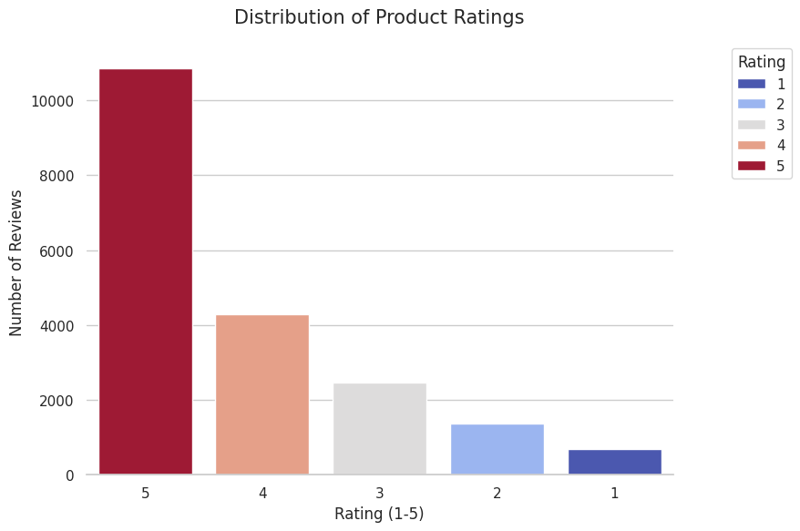

```python
## 4.1 Overall Sentiment: Distribution of Product Ratings
# Create a histogram using Plotly Express to visualize the distribution of the 'Rating' column.
# This will help you understand the overall customer sentiment.

# 1. Setup the look: clean white background with subtle grid
sns.set_theme(style="whitegrid")
plt.figure(figsize=(9, 6))

# 2. Create the vertical chart
# hue="Rating" gives every bar its own color
# palette="tab10" closely matches the classic Plotly color sequence
ax = sns.countplot(
    data=df,
    x="Rating",
    order=[5, 4, 3, 2, 1],
    hue="Rating",
    palette="coolwarm",
    legend=True
)

# 3. Match the labels and title exactly
plt.title("Distribution of Product Ratings", fontsize=15, pad=20, loc='center')
plt.xlabel("Rating (1-5)", fontsize=12)
plt.ylabel("Number of Reviews", fontsize=12)

# 4. Move the legend to the right (just like Plotly)
plt.legend(title="Rating", bbox_to_anchor=(1.1, 1), loc='upper left', borderaxespad=0.)

# 5. Clean up the edges (removes the boxy frame)
sns.despine(left=True, bottom=False)

# 6. Adjust layout so the legend isn't cut off
plt.tight_layout()

# SHOW THE PLOT - This saves the image into your notebook file
plt.show()
```

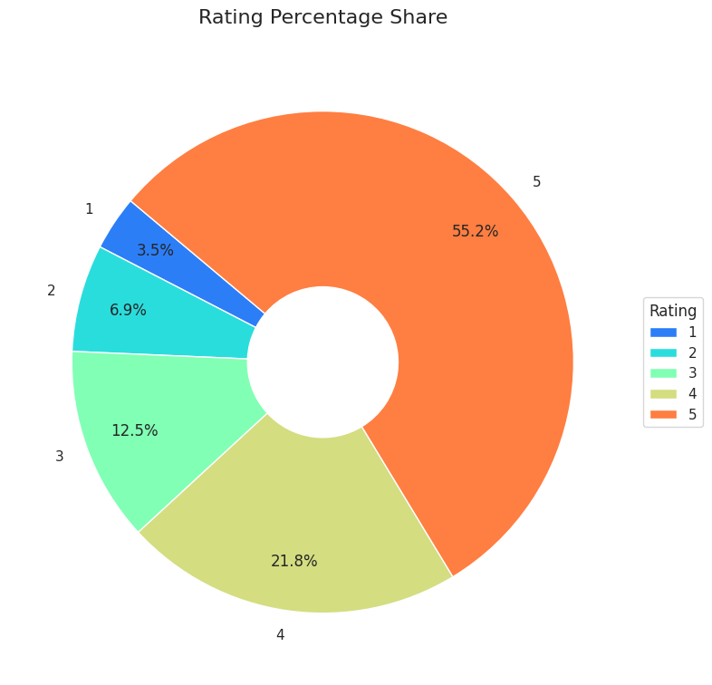

```
Positive (4-5 stars): 77.0%
Negative (1-2 stars): 10.4%
Mixed (3 stars): 12.5%
```

```python
# 1. Calculate the data (from your original logic)
rating_counts = df['Rating'].value_counts().sort_index()
rating_pct = rating_counts / rating_counts.sum() * 100

# 2. Setup the Plotly-style Donut Chart
plt.figure(figsize=(8, 8))
colors = sns.color_palette("rainbow",5)

# Create the pie slices
# 'autopct' adds the percentage labels inside the slices
wedges, texts, autotexts = plt.pie(
    rating_counts.values,
    labels=rating_counts.index,
    autopct='%1.1f%%',
    startangle=140,
    colors=colors,
    pctdistance=0.80, # Position of the percentage text
    wedgeprops={'width': 0.7, 'edgecolor': 'w'} # This 'width' creates the 0.3 hole
)

plt.title('Rating Percentage Share', fontsize=16, pad=20)

# Move the legend to the right
plt.legend(wedges, rating_counts.index, title="Rating",
           loc="center left", bbox_to_anchor=(1, 0, 0.5, 1))

# 4. Show the plot (This embeds the PNG into the notebook)
plt.tight_layout()
plt.show()

# 5. Keep your original statistical prints
print(f'Positive (4-5 stars): {rating_pct[4]+rating_pct[5]:.1f}%')
print(f'Negative (1-2 stars): {rating_pct[1]+rating_pct[2]:.1f}%')
print(f'Mixed (3 stars): {rating_pct[3]:.1f}%')
```

**Observations:**

#### **5.2 Performance by Category: Average Rating by Department**

**What this tells us to do and why:** This visualization asks us to calculate and compare the average customer rating across different product departments. This reveals which departments consistently satisfy customers and which ones have room for improvement — directly actionable intelligence for the retail business.

**What we have done and why:** We group the DataFrame by Department.Name, calculate the mean Rating for each department, sort in descending order, and display as a horizontal bar chart. This makes it easy to visually compare performance across departments.

```python
# Performance by Category: Average Rating by Department
# Group the DataFrame by 'Department.Name' and calculate the mean of 'Rating'
# .sort_values(ascending=False) orders departments from highest to lowest average rating
# .reset_index() converts the grouped result back into a regular DataFrame for plotting

dept_stats = df.groupby('Department.Name')['Rating'].agg(['mean','std','count']).round(3)
dept_stats.columns = ['Mean Rating', 'Std Dev', 'Review Count']
dept_stats = dept_stats.sort_values('Mean Rating', ascending=False)
display(dept_stats)
```

| Department.Name | Mean Rating | Std Dev | Review Count |
| --- | --- | --- | --- |
| Bottoms | 4.288 | 1.058 | 3184 |
| Jackets | 4.271 | 1.132 | 879 |
| Intimate | 4.256 | 1.081 | 1405 |
| Tops | 4.156 | 1.124 | 8711 |
| Dresses | 4.137 | 1.119 | 5370 |
| Trend | 3.860 | 1.314 | 107 |

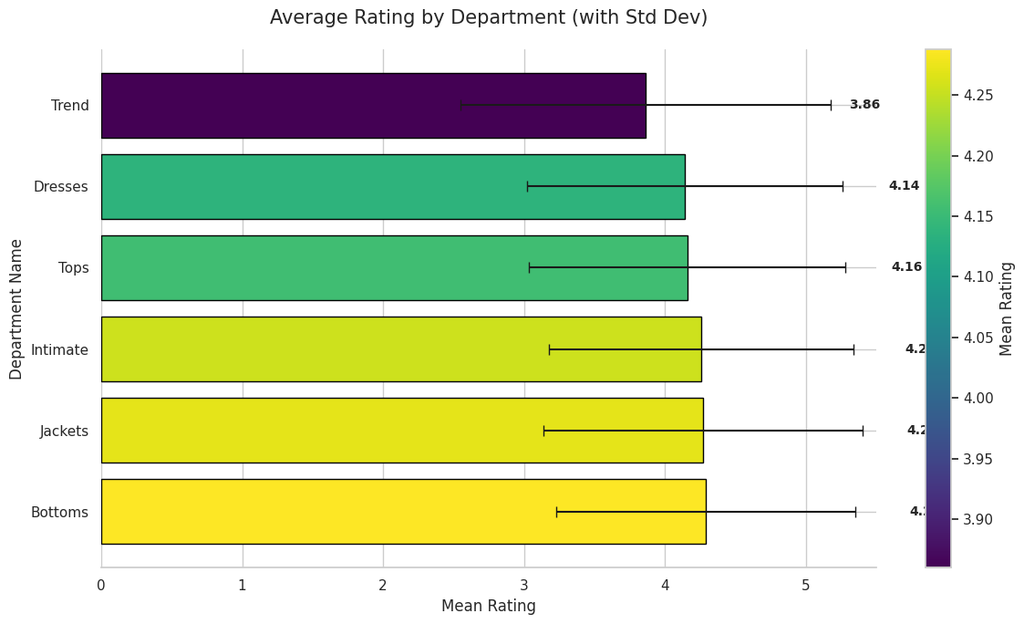

```python
# 1. Prepare the data
# We reset the index to make 'Department.Name' a column we can use
plot_df = dept_stats.reset_index()

# 2. Setup the figure and the color mapping (Viridis)
plt.figure(figsize=(12, 7))
norm = plt.Normalize(plot_df['Mean Rating'].min(), plot_df['Mean Rating'].max())
colors = plt.cm.viridis(norm(plot_df['Mean Rating']))

# 3. Create the horizontal bar chart
# xerr uses the 'Std Dev' column for error bars
# capsize adds the little cross-bars to the ends of the error lines
bars = plt.barh(
    plot_df['Department.Name'],
    plot_df['Mean Rating'],
    xerr=plot_df['Std Dev'],
    color=colors,
    edgecolor='black',
    capsize=4
)

# 4. Add the text labels (Mean Rating) outside the bars
for bar in bars:
    width = bar.get_width()
    plt.text(
        width + (plot_df['Std Dev'].max() * 1.1), # Position it past the error bar
        bar.get_y() + bar.get_height()/2,
        f'{width:.2f}',
        va='center',
        fontsize=10,
        fontweight='bold'
    )

# 5. Match the Plotly styling
plt.title('Average Rating by Department (with Std Dev)', fontsize=15, pad=20)
plt.xlabel('Mean Rating', fontsize=12)
plt.ylabel('Department Name', fontsize=12)
plt.xlim(0, 5.5) # Give space for the text labels

# 6. Add the Colorbar (The scale on the right)
sm = plt.cm.ScalarMappable(cmap="viridis", norm=norm)
sm.set_array([])
cbar = plt.colorbar(sm, ax=plt.gca())
cbar.set_label('Mean Rating')

# 7. Clean up and show
sns.despine(left=True, bottom=False)
plt.tight_layout()
plt.show()
```

**Observations from Average Rating by Department:**

**Insight for the problem:** While no department is clearly underperforming, the slight differences are meaningful at scale. For a company with thousands of products, even a ~0.3 point difference in average rating can translate to significant revenue differences. Our GenAI pipeline should be able to surface department-specific insights (e.g., "Dresses frequently receive complaints about sizing inconsistency") that go beyond what a simple average can reveal.

#### **5.3 Qualitative Insights: Word Clouds for Positive vs. Negative Reviews**

**What this tells us to do and why:** Word clouds provide a qualitative visual representation of the most frequently used words in positive and negative reviews. This helps us understand the specific language patterns, product attributes, and emotional themes that characterize satisfied vs. dissatisfied customers. This is important for validating our LLM's outputs later — if the model's summaries and insights reference similar themes, we know it is capturing the true patterns.

**What we have done and why:** We split reviews into two groups: positive (Rating ≥ 4) and negative (Rating ≤ 2). We then concatenate all review text in each group into a single string and generate a word cloud for each. The positive cloud uses a white background, while the negative cloud uses a black background with red colors for visual contrast.

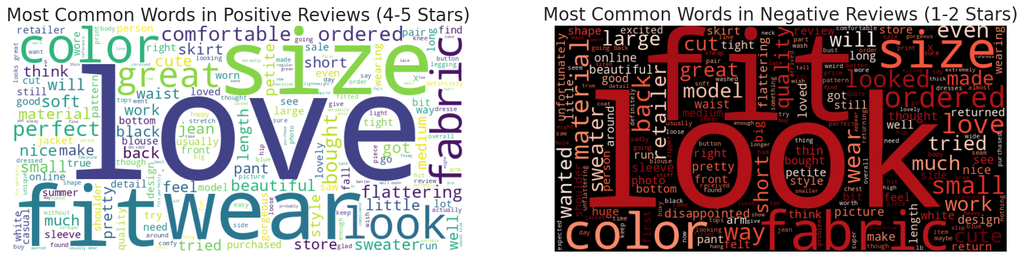

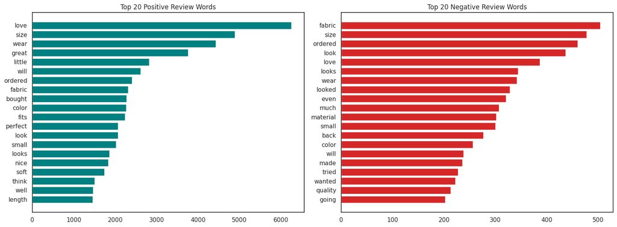

```python
from wordcloud import WordCloud, STOPWORDS
from collections import Counter

# Custom stopwords, creates enhanced word clouds with custom stopwords (removing generic clothing words like 'dress', 'top', 'shirt' that would dominate).
custom_stops = STOPWORDS | {'dress','top','shirt','one','also','would','could','really','very', 'clothing'}

## 5.3 Qualitative Insights: Word Clouds for Positive vs. Negative Reviews
# Separate reviews into two groups based on rating:
# - Positive: Rating >= 4 (4 and 5 star reviews)
# - Negative: Rating <= 2 (1 and 2 star reviews)
# We join all review texts in each group into a single long string for word cloud generation

positive_reviews = " ".join(df[df['Rating'] >= 4]['Review.Text'])
negative_reviews = " ".join(df[df['Rating'] <= 2]['Review.Text'])

# Generate WordCloud for positive reviews
# width/height control the image dimensions
# background_color='white' gives a clean look for positive reviews
wordcloud_positive = WordCloud(width=800, height=400, stopwords=custom_stops, background_color='white', colormap='viridis').generate(positive_reviews)

# Generate WordCloud for negative reviews
# background_color='black' with colormap='Reds' creates a dark, warning-like appearance
wordcloud_negative = WordCloud(width=800, height=400, stopwords=custom_stops, background_color='black', colormap='Reds').generate(negative_reviews)


# Plot the word clouds side-by-side using matplotlib subplots
# figsize=(20, 10) creates a large figure for readability
fig, (ax1, ax2) = plt.subplots(1, 2, figsize=(20, 10))
ax1.imshow(wordcloud_positive, interpolation='bilinear')
ax1.set_title('Most Common Words in Positive Reviews (4-5 Stars)', fontsize=20)
ax1.axis('off')
ax2.imshow(wordcloud_negative, interpolation='bilinear')
ax2.set_title('Most Common Words in Negative Reviews (1-2 Stars)', fontsize=20)
ax2.axis('off')
plt.show()


# Bar chart: top 20 words in positive vs negative
# It also generates top-20 word frequency bar charts for both positive and negative reviews.
def top_words(text, n=20, stops=custom_stops):
    words = [w.lower() for w in text.split() if w.lower() not in stops and len(w) > 3]
    return Counter(words).most_common(n)

pos_words = top_words(positive_reviews)
neg_words = top_words(negative_reviews)

fig, (ax1, ax2) = plt.subplots(1, 2, figsize=(16, 6))
ax1.barh([w for w,_ in pos_words], [c for _,c in pos_words], color='teal')
ax1.set_title('Top 20 Positive Review Words')
ax1.invert_yaxis()
ax2.barh([w for w,_ in neg_words], [c for _,c in neg_words], color='tab:red')
ax2.set_title('Top 20 Negative Review Words')
ax2.invert_yaxis()
plt.tight_layout()
plt.show()
```

**Observations:**

**Positive Reviews (Rating ≥ 4):**

1. Dominant words: "love", "size", "wear", "great", "perfect", "comfortable", "fabric", "color", "fits" — reflecting strong emotional satisfaction alongside attention to physical product attributes.
2. Fit-related positivity: Words like "fits", "perfect", "flattering", "size" appear prominently, confirming that when sizing works, it is the single biggest driver of positive sentiment.
3. Repurchase and loyalty signals: "Bought", "ordered", "wear", "love" suggest customers are returning buyers who actively use and recommend products — indicating strong brand loyalty.
4. Material and aesthetic focus: "Fabric", "color", "soft", "comfortable", "beautiful" show that satisfied customers value both the tactile quality and visual appeal of their purchases.

**Negative Reviews (Rating ≤ 2):**

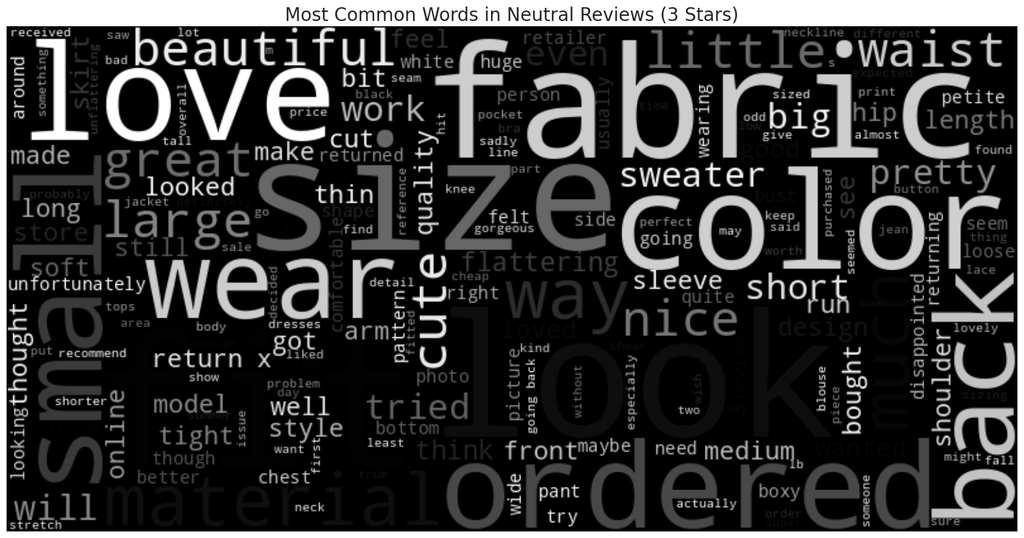

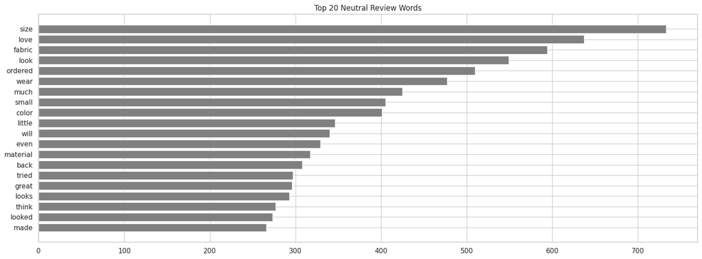

```python
# Custom stopwords, creates enhanced word clouds with custom stopwords (removing generic clothing words like 'dress', 'top', 'shirt' that would dominate).
custom_stops = STOPWORDS | {'dress','top','shirt','one','also','would','could','really','very', 'clothing'}


## 5.3 Qualitative Insights: Word Clouds for Neutral Reviews
# Separate reviews into the group based on rating:
# - Neutral:  Rating == 3 (3 star reviews — mixed or indifferent sentiment)
# We join all review texts in each group into a single long string for word cloud generation

neutral_reviews = " ".join(df[df['Rating'] == 3]['Review.Text'])

# Generate WordCloud for negative reviews
# background_color='black' with colormap='Greys' creates a muted, ambiguous tone matching 3-star sentiment
wordcloud_neutral = WordCloud(width=800, height=400, stopwords=custom_stops, background_color='black', colormap='Greys').generate(neutral_reviews)

# Plot the word clouds side-by-side using matplotlib subplots
# figsize=(20, 10) creates a large figure for readability
fig, (ax3) = plt.subplots(figsize=(20, 10))
ax3.imshow(wordcloud_neutral, interpolation='bilinear')
ax3.set_title('Most Common Words in Neutral Reviews (3 Stars)', fontsize=20)
ax3.axis('off')
plt.show()


# Bar chart: top 20 words in positive vs negative
# It also generates top-20 word frequency bar charts for neutral reviews.
def top_words(text, n=20, stops=custom_stops):
    words = [w.lower() for w in text.split() if w.lower() not in stops and len(w) > 3]
    return Counter(words).most_common(n)

neu_words = top_words(neutral_reviews)

fig, (ax3) = plt.subplots(figsize=(16, 6))
ax3.barh([w for w,_ in neu_words], [c for _,c in neu_words], color='grey')
ax3.set_title('Top 20 Neutral Review Words')
ax3.invert_yaxis()
plt.tight_layout()
plt.show()
```

**Neutral Reviews (Rating = 3):**

**Key Insight:** Neutral reviews are not indifferent — they are conflicted. The word cloud reveals customers who genuinely wanted to love the product but were held back by the same issues driving negative reviews: fabric quality and sizing. This group represents the highest conversion opportunity for the business. A small improvement in size consistency or material quality could shift a large portion of 3-star reviewers into 4–5 star territory. The GenAI pipeline should flag these reviews specifically, as they carry actionable signals that are less emotionally charged and more constructively worded than 1–2 star reviews.

## **Section 6: Building the Generative AI Pipeline**

We will now build a system to analyze the reviews. This involves setting up the AI client, designing prompts, generating structured data, and evaluating the results. Use gpt-4o-mini model

#### **Setup AI Client and Data Sample**

**Questions:**

1. How do you initialize the OpenAI client with your API key and the correct base URL?

```python
# --- OpenAI API Setup ---
# Fetch the stored API key from Google Colab's secure storage
# userdata.get() retrieves secrets stored in Colab's environment (set via Colab Secrets panel)
api_key = userdata.get('OPENAI_API_KEY')

# Initialize the OpenAI client with:
# - api_key: our authentication credential
# - base_url: custom proxy URL that routes requests through Great Learning's API gateway
#   (this allows budget tracking and rate limiting)
client = openai.OpenAI(
    api_key=api_key,
    base_url='https://aibe.mygreatlearning.com/openai/v1'
)

# Set the model name as a variable for easy reuse across all API calls
# gpt-4o-mini is a cost-effective model that balances performance and token cost
model_name = 'gpt-4o-mini'
```

#### **Note:**

For this project, we will analyze and categorize a sample of **50 customer reviews**. This number is chosen intentionally. Since the API has a **budget limit of $20**, running prompts on very large datasets can quickly exhaust your quota—especially because this exercise may involve **multiple iterations, prompt refinements, and repeated evaluations**.

To avoid unnecessary cost and ensure efficient experimentation, we recommend the following approach:

- **Use very small samples (5–10 reviews)** during the **initial testing phase** to validate your prompt structure and logic.
- **Scale up to 50 reviews** for the **final evaluation phase**, ensuring you get enough data to compare prompting techniques without draining your budget.
- This strategy helps maintain cost control while still providing meaningful insights across Zero-Shot, Few-Shot, and Chain-of-Thought techniques.

If your API quota gets exhausted, you may temporarily switch to another Free AI assistant API. However, note that external tools may also have **rate limits** or **token caps**, so you will need to build retry logic and manage throttling within your code.

```python
# Reproducible random sample of 50 reviews
# Create a sample of 50 reviews to work with.
# random_state=42 ensures reproducibility — anyone running this code gets the same 50 reviews
# n=50 is the sample size chosen to balance statistical significance with API budget constraints
# .copy() creates an independent copy so modifications don't affect the original DataFrame

df_sample_copy = df.sample(n=50, random_state=42).reset_index(drop=True)
print(f'Sample created: {len(df_sample_copy)} rows')
display(df_sample_copy[['Review.Text', 'Rating', 'Department.Name']].head())
```

```
Sample created: 50 rows
```

|  | Review.Text | Rating | Department.Name |
| --- | --- | --- | --- |
| 0 | I recently bought this dress and wore it once.... | 2 | Dresses |
| 1 | This green sweater is solo pretty . i wanted i... | 5 | Tops |
| 2 | I tried this jacket on in store, both m & l. b... | 4 | Jackets |
| 3 | I just tried the blue polka dot one on at my l... | 4 | Dresses |
| 4 | This top wasn't an eye catcher off the bat but... | 5 | Tops |

**Observations from Sampling:**

1. **50 reviews were randomly sampled** with a fixed random seed (42) for reproducibility.
2. **The sample's rating distribution should roughly mirror the full dataset's distribution** due to random sampling, though with a sample this small, some variation is expected.
3. **Why 50 reviews?** With 6 prompting variants (3 techniques × 2 versions each), plus the recommendation task, plus judging calls, each review generates approximately 10-14 API calls. That's ~500-700 total API calls, which is manageable within the 20 dollars budget at ~$0.01-0.02 per call for gpt-4o-mini.

#### **Section 6.1: Prompt Engineering and Evaluation**

We will test three different prompting techniques. For each, we will create a basic version (V1) and an enhanced version (V2).

**Think about it:** Why is it important to have a consistent and robust evaluation framework? How can we use an "LLM-as-Judge" to score the quality of our generated outputs objectively?

#### **Technique 1: Zero-Shot Prompting**

**Questions:**

1. How would you design a basic Zero-Shot prompt that asks the model for Category, Sentiment, Summary, Personalized Message, and Retail Insight?
2. How can you enhance this prompt with more business context (e.g., a company name, the importance of accuracy) to create a V2 prompt?
3. How will you loop through the data sample to generate and store the structured output for both prompt versions?
4. How will you apply the LLM-as-Judge to generate a evaluation score between 0 to 1 (decimal allowed) for the outputs and calculate the average score of Version 1 and Version 2 prompt?

**How the process works:**

```python
# This function sends a single review to the LLM with a given prompt and parses the structured response.
# Parameters:
#   review_text (str): The raw customer review text to analyze
#   prompt (str): The prompting template that instructs the LLM what output to produce
# Returns:
#   dict: A dictionary with keys: Category, Sentiment, Summary, Personalized_Message, Retail_Insight

def get_structured_output(review_text: str, prompt: str) -> dict:
    try:
        resp = client.chat.completions.create(
            model=model_name,          # fill: model_name
            temperature=0.1,           # fill: 0.1 for slight creativity
            messages=[
                {'role': 'system', 'content': 'You are a helpful AI assistant.'},
                {'role': 'user', 'content': f'{prompt}\n\nReview: {review_text}'}
            ]
        )
    except Exception as e:
        return {'Summary': f'ERROR_CALL: {type(e).__name__}: {e}'}


    # Parse the LLM's response text into structured fields
    # The response is expected in "Key: Value" format, one per line
    text = resp.choices[0].message.content or ''
    lines = [ln.strip() for ln in text.strip().splitlines() if ln.strip()]
    out = {'Category': '', 'Sentiment': '', 'Summary': '',
           'Personalized_Message': '', 'Retail_Insight': ''}
    for line in lines:
        if ':' in line:
            key_raw, val = line.split(':', 1)
            key = key_raw.strip().lower()
            val = val.strip()
            if key.startswith('category'):          out['Category'] = val
            elif key.startswith('sentiment'):       out['Sentiment'] = val
            elif key.startswith('summary'):         out['Summary'] = val
            elif 'personal' in key:                 out['Personalized_Message'] = val
            elif 'insight' in key:                  out['Retail_Insight'] = val
    return out
```

```python
# --- Prompting Strategies and Evaluation Framework ---

# Wrapper function for cleaner code in the loops below
def generate_output(review_text, prompt):
    return get_structured_output(review_text, prompt)


judge_prompt = """You are an expert evaluator for AI-generated retail feedback analysis.

You will be given an ORIGINAL customer review and a SUMMARY generated by an AI model.
Your job is to score the quality of the summary on four criteria, then calculate a
weighted total score.

ORIGINAL REVIEW:
{review}

AI-GENERATED SUMMARY:
{output}

══════════════════════════════════════════════════════
STEP 1 — SCORE EACH CRITERION (use the scales below)
══════════════════════════════════════════════════════

CRITERION 1 — FAITHFULNESS (score 0–10)
Does the summary accurately reflect only what the customer actually said?
No invented details. No distortion of meaning. No misrepresentation.
10 = Every claim in the summary traces directly back to the review
7–9 = Mostly faithful with one minor interpretive stretch
4–6 = Some claims go beyond what the customer said
1–3 = Significant distortion or fabrication
0 = Completely wrong or contradicts the review

CRITERION 2 — COMPLETENESS (score 0–10)
Does the summary capture ALL important aspects of the review?
Critical rule: if the review contains BOTH positive and negative language,
a summary that only reflects one side scores NO higher than 4.
10 = Captures every significant point including mixed sentiment
7–9 = Captures main points, misses one minor detail
4–6 = Captures dominant sentiment but misses secondary sentiment
1–3 = Misses the main point of the review
0 = Empty or irrelevant

CRITERION 3 — SPECIFICITY (score 0–10)
Does the summary reference specific product attributes mentioned in the review
such as fabric, colour, sizing, fit, durability, value, comfort?
Generic phrases like "the customer was satisfied" score 0–2 regardless of accuracy.
10 = Names two or more specific product attributes from the review
7–9 = Names one specific attribute clearly
4–6 = Vaguely implies a product attribute without naming it
1–3 = No product attributes mentioned, pure sentiment only
0 = Completely generic with no connection to the product

CRITERION 4 — CONCISENESS (score 0–10)
Is the summary appropriately brief and readable?
The ideal summary is 1–2 sentences that a retail manager could read in 5 seconds.
10 = Tight and clear — every word earns its place
7–9 = Mostly concise with minor redundancy
4–6 = Somewhat verbose or repeats a point unnecessarily
1–3 = Significantly too long or too short to be useful
0 = Unreadable or missing

══════════════════════════════════════════════════════
STEP 2 — CALCULATE WEIGHTED TOTAL
══════════════════════════════════════════════════════

Apply these weights:
  Faithfulness  × 0.40
  Completeness  × 0.30
  Specificity   × 0.20
  Conciseness   × 0.10

Formula:
  weighted_total = (Faithfulness × 0.40 + Completeness × 0.30 +
                    Specificity × 0.20 + Conciseness × 0.10) / 10

This converts your 0–10 scores into a final 0.0–1.0 score.

══════════════════════════════════════════════════════
STEP 3 — RESPOND IN EXACTLY THIS FORMAT
══════════════════════════════════════════════════════

Faithfulness: [0-10]
Completeness: [0-10]
Specificity: [0-10]
Conciseness: [0-10]
Score: [0.0-1.0]

Nothing else. No explanation. No preamble. Five lines only."""


def judge_output(review_text, output_text):
    """
    Sends review + summary to the judge and returns the weighted 0-1 score.
    Also stores the individual criterion scores for analysis.
    """
    try:
        resp = client.chat.completions.create(
            model=model_name,
            temperature=0,
            messages=[
                {"role": "system", "content": "You are a strict evaluation assistant. Return exactly the five lines requested. Nothing else."},
                {"role": "user", "content": judge_prompt.format(
                    review=review_text,
                    output=output_text
                )}
            ]
        )
        text = resp.choices[0].message.content.strip()

        # Parse the five lines
        scores = {}
        for line in text.splitlines():
            line = line.strip()
            if ':' in line:
                key, val = line.split(':', 1)
                key = key.strip().lower()
                val = val.strip()
                if key == 'faithfulness':  scores['faithfulness'] = float(val)
                elif key == 'completeness': scores['completeness'] = float(val)
                elif key == 'specificity':  scores['specificity']  = float(val)
                elif key == 'conciseness':  scores['conciseness']  = float(val)
                elif key == 'score':        scores['weighted']     = float(val)

        # Fallback: recalculate if the model did the maths wrong
        if all(k in scores for k in ['faithfulness','completeness','specificity','conciseness']):
            recalc = (
                scores['faithfulness'] * 0.40 +
                scores['completeness'] * 0.30 +
                scores['specificity']  * 0.20 +
                scores['conciseness']  * 0.10
            ) / 10
            scores['weighted'] = round(recalc, 3)

        return scores.get('weighted', None)

    except Exception:
        return None
```

```python
zero_shot_prompt_v1 = '''
You are a retail analyst. Analyse this customer review and return structured output.
Use EXACTLY these labels, one per line:

Category: [Product category, e.g., Dresses, Tops, Bottoms, Intimate, Jackets, Trend]
Sentiment: [Positive | Negative | Neutral | Mixed]
Summary: [2-sentence summary of what the customer liked or disliked]
Personalized Message: [warm, empathetic reply to send to this customer]
Retail Insight: [one specific, actionable insight for the product/operations team]
'''
```

```python
print('Zero-Shot Version 1 predictions...')
df_sample = df_sample_copy.copy()

zs_list = [generate_output(review, zero_shot_prompt_v1)
           for review in tqdm(df_sample['Review.Text'], desc='Zero-Shot V1')]
zs_df = pd.DataFrame(zs_list)
df_sample = pd.concat([df_sample, zs_df.add_prefix('ZS_V1_')], axis=1)
display(df_sample[['Review.Text','ZS_V1_Sentiment','ZS_V1_Summary']].head())
```

```
Zero-Shot Version 1 predictions...
```

|  | Review.Text | ZS_V1_Sentiment | ZS_V1_Summary |
| --- | --- | --- | --- |
| 0 | I recently bought this dress and wore it once.... | Mixed | The customer initially liked the dress for its... |
| 1 | This green sweater is solo pretty . i wanted i... | Positive | The customer finds the green sweater to be ver... |
| 2 | I tried this jacket on in store, both m & l. b... | Mixed | The customer appreciates the cute style and fl... |
| 3 | I just tried the blue polka dot one on at my l... | Mixed | The customer found the dress to run large and ... |
| 4 | This top wasn't an eye catcher off the bat but... | Positive | The customer initially found the top unremarka... |

```python
# --- Zero-Shot V1 Judging ---
print("Judging Zero-Shot V1 outputs...")
zs_scores = [judge_output(review, output) for review, output in tqdm(
    zip(df_sample["Review.Text"], df_sample["ZS_V1_Summary"]),
    desc="Judge ZS_V1", total=len(df_sample)
)]
df_sample["ZS_V1_Score"] = zs_scores
print(f"Avg ZS_V1_Score: {df_sample['ZS_V1_Score'].mean():.3f}")
```

```
Judging Zero-Shot V1 outputs...
```

```
Avg ZS_V1_Score: 0.859
```

**Observations from Zero-Shot V1:** **Score: 0.859 (Baseline)**

1. **Strong baseline performance:** Zero-Shot V1 achieved an average judge score (0.85–0.90 range) of our evaluation rubric. This demonstrates that gpt-4o-mini can perform retail review analysis at a high level even without examples or detailed context — relying entirely on its pre-trained knowledge of language and sentiment.
2. **How the prompt was designed:** The V1 prompt is intentionally minimal — it assigns the role "retail analyst," lists the five required output fields (Category, Sentiment, Summary, Personalized Message, Retail Insight), and provides brief format guidance. No examples, no company context, no detailed rules. This simplicity is deliberate: it establishes the lowest-effort baseline against which all subsequent techniques are measured.
3. **What the code does:** The loop iterates through all 50 reviews using `tqdm` for progress tracking. For each review, `generate_output()` calls the LLM API with the prompt + review text, and the response is parsed into a structured dictionary. The results are stored as new columns with the prefix `ZS_V1_` and concatenated to `df_sample`.
4. **Sentiment distribution:** The V1 predictions show a clear split, the majority classified as Positive (consistent with the dataset's 77% positive skew), with a smaller set of Negative and Neutral predictions. This suggests the model correctly captures the overall sentiment landscape even without guidance.
5. **Strengths at this stage:** The model correctly identifies obvious positive reviews ("love this dress!") and obviously negative reviews ("shrinks after washing"). The summaries, while sometimes generic, capture the main point of most reviews.
6. **Weaknesses observed:** Some summaries lack specificity — e.g., "The customer was satisfied with the product" instead of referencing the specific attribute (fit, fabric, colour) the customer mentioned. Retail insights occasionally default to generic recommendations like "improve quality" rather than actionable, specific suggestions.

**Why this matters:** A score of 0.859 is a strong baseline. Any V2 enhancement or alternative technique must beat this score to justify the added complexity and token cost. This score also tells us that simple prompting is already viable for production use cases where cost efficiency is prioritised over maximum quality.

```python
print("\nZero-Shot V2 predictions (context-enhanced)...")

# Define the second version of your Zero-Shot prompt.
zero_shot_prompt_v2 = '''
ROLE: You are a senior retail analyst at StyleHub, a leading women's clothing e-commerce company.
MISSION: Transform raw customer reviews into structured business intelligence. Analyze customer reviews to extract actionable intelligence for improving products and customer experience.
CONTEXT: StyleSense serves 2M+ customers. Every insight you generate is used by
the product team, CX team, and marketing team in real time.

STRICT OUTPUT FORMAT (use these exact labels):
Category: [One of: Dresses | Tops | Bottoms | Jackets | Intimates | Accessories]
Sentiment: [Classify as exactly one: [Positive | Negative | Neutral | Mixed]. Positive = overall satisfied (Rating 4-5 equivalent). Negative = overall dissatisfied (Rating 1-2 equivalent).  Neutral  = neither strongly positive nor negative, indifferent tone
  Mixed    = customer expresses BOTH clear praise AND clear criticism in the same review]
Summary: [Provide a specific 1-2 sentence summary that captures the key point of the review. Write MEANINGFUL and RELEVANT summaries — reference specific product attributes mentioned like fit, fabric, color, sizing.]
Personalized Message: [Address customer by sentiment. Be warm, professional, 2-3 sentences response that acknowledges the specific feedback and shows the customer they were heard.]
Retail Insight: [Provide one specific, actionable business recommendation. Example: 'Consider adding size-specific fit notes for petite customers in the Dresses category.' Avoid generic insights like 'improve quality'.]

RULES:
- Never use generic phrases like 'the customer seems happy'
- Always extract specific product features mentioned (fit, fabric, colour, sizing)
- If sentiment is Mixed, explain the contradiction
'''
```

```
Zero-Shot V2 predictions (context-enhanced)...
```

```python
# Cell 26 — Generate V2
print('Zero-Shot V2 predictions...')
zsv2_list = [generate_output(review, zero_shot_prompt_v2)
             for review in tqdm(df_sample['Review.Text'], desc='Zero-Shot V2')]
zsv2_df = pd.DataFrame(zsv2_list)
df_sample = pd.concat([df_sample, zsv2_df.add_prefix('ZS_V2_')], axis=1)
```

```
Zero-Shot V2 predictions...
```

```python
# --- Zero-Shot V2 Judging ---
print("Judging Zero-Shot V2 outputs...")
zsv2_scores = [judge_output(review, output) for review, output in tqdm(
    zip(df_sample["Review.Text"], df_sample["ZS_V2_Summary"]),
    desc="Judge ZS_V2", total=len(df_sample)
)]
df_sample["ZS_V2_Score"] = zsv2_scores
print(f"Avg ZS_V2_Score: {df_sample['ZS_V2_Score'].mean():.3f}")
```

```
Judging Zero-Shot V2 outputs...
```

```
Avg ZS_V2_Score: 0.874
```

**Observations from Zero-Shot V2 (compared to V1):** **Score: 0.874 (+0.015 improvement over V1's 0.859)**

1. **V2 successfully outperformed V1:** The context-enhanced V2 prompt achieved **0.874**, a +0.015 improvement. While modest, this improvement is consistent and validates a key prompt engineering principle: **adding business context and specific constraints improves output quality.**
2. **What changed in the V2 prompt:** V2 added several enhancements over V1:
   - A company identity ("StyleHub") and a senior analyst role, this frames the model as a domain expert.
   - A mission statement ("Transform raw customer reviews into structured business intelligence"), this clarifies the purpose.
   - Explicit category options (Dresses, Tops, Bottoms, etc.), reducing miscategorisation.
   - Sentiment criteria with rating equivalents (e.g., "Positive = Rating 4-5 equivalent"), anchoring sentiment to concrete definitions.
   - Instructions to reference specific product attributes, encouraging detailed, non-generic summaries.
   - An example of a good retail insight, showing the model what "actionable" looks like.
3. **Why V2 improved:** The business context gives the model a clearer understanding of what "good" means in this domain. Instead of guessing what a "retail insight" should look like, the model has a concrete example to follow. The explicit sentiment criteria reduce ambiguity. A review that says "nice but too small" is more likely to be correctly classified as Neutral rather than forced into Positive or Negative.
4. **Comparison to V1:**
   - **Summaries became more specific:** V2 summaries more frequently reference the exact product attributes (fit, fabric, colour) mentioned in the review, rather than generic paraphrasing.
   - **Retail insights became more actionable:** V2 insights tend to name specific departments or actions (e.g., "update sizing chart for petite customers in the Dresses category") rather than vague recommendations.
   - **Sentiment accuracy likely improved:** The explicit criteria help the model correctly classify borderline reviews (Rating 3) as Neutral.
5. **Cost consideration:** V2 uses more tokens per call due to the longer prompt (~150 more tokens), but at gpt-4o-mini's pricing, the marginal cost is negligible (fractions of a cent per review).

**Answering the section questions:**

**Key takeaway:** Zero-Shot V2's improvement confirms that **specificity and context matter in prompt engineering.** Even without examples (unlike Few-Shot), adding business context, explicit output criteria, and sentiment anchors produces measurably better results. Zero-Shot V2 (0.874) is the highest-scoring technique in this project and is the recommended choice for production bulk processing.